# Water Level station

Monitoring the Renaturation process of the Aa river in Münster Unmmanned Aerial Systems

senseBox group

July 12, 2018

## Introduction

The water level station objective was to track changes of the water level of the river Aa on the site of renaturation. The station was equipped with two Ultrasonic Distance sensors, in case of failure of one of them. The data was recorded on an SD card while on the field every ten seconds, including a timestamp for each log.

The construction of the logger required the use of the basic sensors available in the senseBox, the senseBox shield which includes a microSD socket and a Real-Time-Clock, as well as a container to place the built logger in, and to place it on the study area in an isolated manner. Figure 1 shows the logger built and placed on the study area.

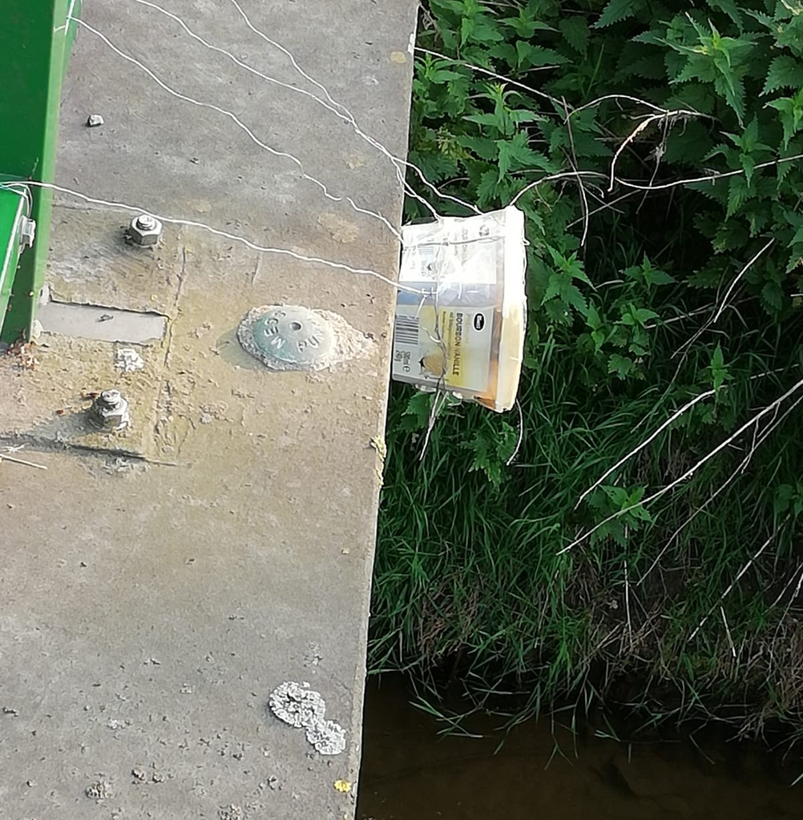

**Fig. 1:** Water level station on the field

## Materials

To build this logger, as well as the other loggers for the current project, we made use of the [senseBox:edu toolkit](https://sensebox.de/en/products). For this project, we used the previous senseBox version, therefore, the documentation on the site might have changed, but is still supported. The senseBox used is based on an [Arduino Genuino Uno board](https://www.arduino.cc/en/Guide/BoardAnatomy), on which, an user-friendly and easy-to-learn programming language can be used to configure the logger. The code used for this particular logger can be found on the section Arduino code.

The materials to build the logger are listed below:

- senseBox:edu box items:
  - Arduino Genuino Uno board
  - [senseBox shield](https://learn.watterott.com/sensebox/shield/)
  - 2 [HC-SR04](http://biblioteca.geekfactory.mx/Sensor_HC-SR04/DS_HC-SR04.pdf) Ultrasonic Distance Sensor
  - Breadboard
  - Jumper wires
  - Resistors
  - USB cable
  - AA battery holder
- 6 AA batteries
- microSD card
- Battery CR2032

Two distance sensors were used, in case of failure of one. The container was isolated with sylicon to avoid water contact with the inner connections, in case of rain.

## Wiring

The following figure illustrates the wiring of the logger. The illustration was made with the [Fritzing](http://fritzing.org/home/) software.

**NOTE:** The board used to connect the sensors was the senseBox shield, however, its illustration was not available on Fritzing. The microSD socket and the RV-8523 RTC (I2C Real-Time-Clock) are built onto that shield, and therefore do not appear on the figure.

[figure not shown]

**Fig. 2:** Water level station wiring

## Arduino code

**NOTE:** The timestamp is recorded by the Real-Time-Clock on the senseBox shield. The time has to be configured only one time when loading the code, and the time can be changed on the setup section of the code, now commented.

```r
/*
 * Water level data logger saves to an SD card with a timestamp for each record
 *
 * senseBox Group
 * Unmanned Aerial Systems
 * Geospatial Technologies MSc.
 *
 * Institute for Geoinformatics, University of Muenster
 * May. 2018
*/

//Libraries loaded
#include <SPI.h> // library to save to SD card
#include <SD.h> // library for SD card
#include <RV8523.h> // library for getting timestamp
//#include <LiquidCrystal.h>

#define trigPin1 3
#define echoPin1 2
#define trigPin2 8
#define echoPin2 7

long duration, distance, RightSensor,BackSensor,FrontSensor,LeftSensor;

// Timestamp logging initial setup
RV8523 rtc;

uint8_t sec, min, hour, day, month;
uint16_t year;

// SD card initial setup
const int chipSelect = 4;

void setup()
{
 //rtc.set( 30, 05, 16, 9, 6, 2018); // 13:32:00 18.05.2018 Only use one time
  rtc.start();

 Serial.begin(9600);
  while (!Serial) {
    ;
  }

  Serial.print("Initializing SD-Card");
   // Check if an SD card is inserted.
  if (!SD.begin(chipSelect)) {
    Serial.println("Card not found");
    return;
  }
  Serial.println("Card succesfully initialized");

  File dataFile = SD.open("datalog.csv", FILE_WRITE);
  dataFile.println(" Timestamp; LeftSensor (cm); RightSensor (cm)");
  dataFile.close();
pinMode(trigPin1, OUTPUT);
pinMode(echoPin1, INPUT);
pinMode(trigPin2, OUTPUT);
pinMode(echoPin2, INPUT);
}

void loop() {
// Read out the sensors and write the data on SD card
  File dataFile = SD.open("datalog.csv", FILE_WRITE);

  //RTC-RV8523
  rtc.get(&sec, &min, &hour, &day, &month, &year); // Read timestamp

  Serial.print("Timestamp:      ");
      Serial.print(hour); Serial.print(":"); Serial.print(min); Serial.print(":");
      Serial.print(sec); Serial.print("  "); Serial.print(day); Serial.print(".");
      Serial.print(month); Serial.print("."); Serial.println(year);

  //call the function and get the distance for each sensor
SonarSensor(trigPin1, echoPin1);
RightSensor = distance;
 if(RightSensor == 0) // If we timed out
  {
    pinMode(echoPin1, OUTPUT); // Then we set echo pin to output mode
    digitalWrite(echoPin1, LOW); // We send a LOW pulse to the echo pin
    delayMicroseconds(200);
    pinMode(echoPin1, INPUT); // And finaly we come back to input mode
  }
SonarSensor(trigPin2, echoPin2);
LeftSensor = distance;
 if(LeftSensor == 0) // If we timed out
  {
    pinMode(echoPin2, OUTPUT); // Then we set echo pin to output mode
    digitalWrite(echoPin2, LOW); // We send a LOW pulse to the echo pin
    delayMicroseconds(200);
    pinMode(echoPin2, INPUT); // And finaly we come back to input mode
  }

Serial.print("LeftSensor: ");
Serial.println(LeftSensor);
Serial.print("RightSensor: ");
Serial.println(RightSensor);
// When the file is open
  if (dataFile) {
    dataFile.print(year,DEC);
    dataFile.print("/");
    dataFile.print(month,DEC);
    dataFile.print("/");
    dataFile.print(day,DEC);
    dataFile.print(" ");
    dataFile.print(hour,DEC);
    dataFile.print(":");
    dataFile.print(min,DEC);
    dataFile.print(":");
    dataFile.print(sec);// Save timestamps
    dataFile.print(";");
    // Save the distance on the file
    dataFile.print(LeftSensor);
    dataFile.print(";");
    dataFile.print(RightSensor);
    dataFile.println(";");
    dataFile.close();
    }
  // If the file can not be opened, an error message should be issued
  else {
    Serial.println("Error opening!");
         }
delay(10000);
}

//function sonsarSensor that evaluates each sensor with its parameters
void SonarSensor(int trigPin,int echoPin)
{
digitalWrite(trigPin, LOW);
delayMicroseconds(2);
digitalWrite(trigPin, HIGH);
delayMicroseconds(10);
digitalWrite(trigPin, LOW);
duration = pulseIn(echoPin, HIGH);
distance = (duration/2) / 29.1;
}
```

## Example of output

This is an example of the output data logged with the code loaded to the logger. There are two columns, left and right sensor, which correspond both to the Ultrasonic Distance sensors. The purpose of using two, was to have a backup in case one of them stops recording. Also a power cut on the logger may resert the clock recording the timestamp. Therefore, cleaning the data and averaging both values collected by the sensors is recommended.

```
##           Timestamp LeftSensor..cm. RightSensor..cm.
## 1 6/9/2018 16:06:16              82                0
## 2 6/9/2018 16:06:27              73               81
## 3 6/9/2018 16:06:37              69               82
## 4 6/9/2018 16:06:47             160              160
## 5 6/9/2018 16:06:57              75               80
## 6 6/9/2018 16:07:07              79               80
```